# Part II - (Ford GoBike System Data Explanation)

## by (Huda Taha)

## Investigation Overview

In this analysis, the primary focus is on trip duration and how it is affected by the other characteristics, such as age, gender, and user type.

## Dataset Overview

The FordBike system is a public bicycle sharing program that has been deployed in the San Francisco Bay Area and along the West Coast of California. Bay Wheels offers a broad range of bicycle sharing services at a regional scale.This data set includes information about individual rides made in a bike-sharing system.I will explore and analysis the data set to explore some insights .

## (Visualization 1 : Age Distrubution)

Most of Ford GoBike riders are people between 20 to 40 years old

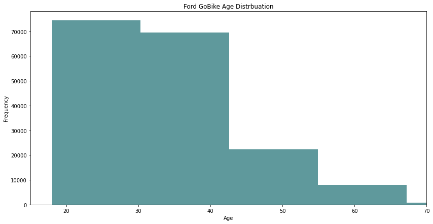

## (Visualization 2 : Ford GoBike Gender Distrubation)

> You will observe from the below graph that Males represents 74.6% of the total data set while Femlas represents only 23.3%

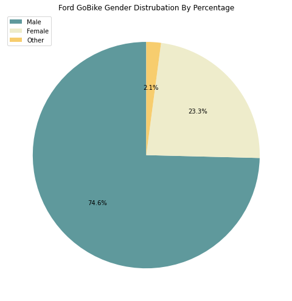

## (Visualization 3 : Ford GoBike User Type Distrubation)

Most Of Ford GoBike clients are subscribers . As showen in the below graph Subscribers proportion is around 8x Customers proportion . .

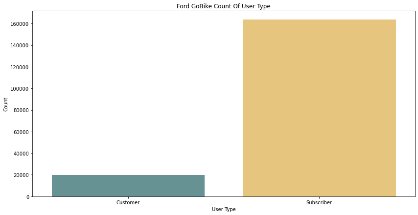

## (Visualization 4 : Ford GoBike Start Trip Hour Distrubutions)

The hourly distribution shows that the most trips occur around 8-9am and 5-6pm .These findings are reflect that trips at 8-9am are more likely to be to the work or school, And trips at 5-6pm are more likely to be from work or school.

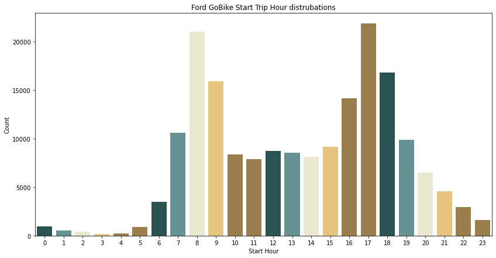

## (Visualization 5: Gender And Trip Duration In Minutes)

Although the fact that males represent the biggest proportion of the dataset . Females bikers takes longer trips compared to male bikers

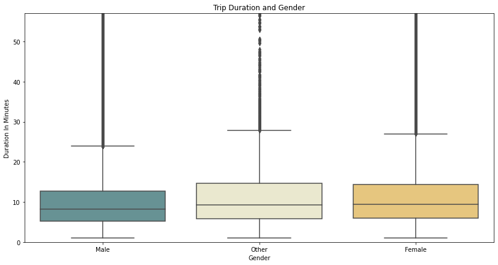

## (Visualization 6 : User Type And Trip Duration In Minutes)

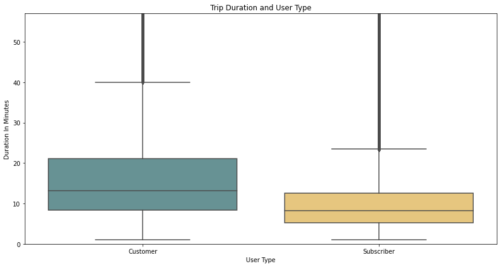

## (Visualization 7 : Trip Duration Based On Age)

Users between the ages of 20 and 40 spend more time biking, which is very reasonable given that biking is affected by the health of the person.

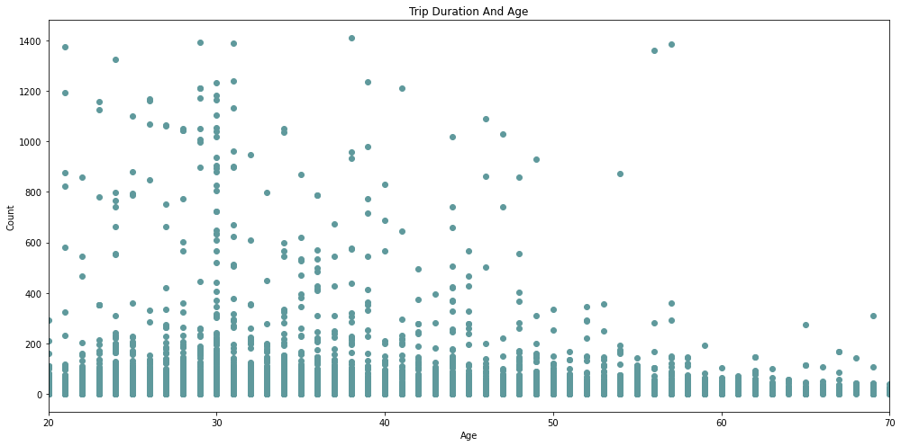